# Practical Machine Learning

12 May, 2015

## Prediction Assignment

### Background

Using devices such as JawboneUp, NikeFuelBand, and Fitbitit is now possible to collect a large amount of data about personal activity relatively inexpensively. These type of devices are part of the quantified self movement - a group of enthusiasts who take measurements about themselves regularly to improve their health, to find patterns in their behavior, or because they are tech geeks. One thing that people regularly do is quantify how much of a particular activity they do, but they rarely quantify how well they do it.

In this project, the goal is to use data from accelerometers on the belt, forearm, arm, and dumbell of 6 participants. They were asked to perform barbell lifts correctly and incorrectly in 5 different ways. More information is available from the website: http://groupware.les.inf.puc-rio.br/har (see the section on the Weight Lifting Exercise Dataset).

### Data Preparation

Loading required packages, and enable the cache options.

```r
library(knitr)
library(ggplot2)
library(caret)
library(corrplot)
library(Rtsne)
library(xgboost)
library(stats)
knitr::opts_chunk$set(cache=TRUE)
```

Loading the data sets from Internet.

```r
# URL of the training and testing data
train.url ="https://d396qusza40orc.cloudfront.net/predmachlearn/pml-training.csv"
test.url = "https://d396qusza40orc.cloudfront.net/predmachlearn/pml-testing.csv"
# file names
train.name = "./data/pml-training.csv"
test.name = "./data/pml-testing.csv"
if (!file.exists("./data")) {
  dir.create("./data")
}
if (!file.exists(train.name)) {
  download.file(train.url, destfile=train.name, method="curl")
}
if (!file.exists(test.name)) {
  download.file(test.url, destfile=test.name, method="curl")
}
train = read.csv("./data/pml-training.csv")
test = read.csv("./data/pml-testing.csv")
dim(train)
```

```
## [1] 19622   160
```

```r
dim(test)
```

```
## [1]  20 160
```

```r
names(train)
```

```
##   [1] "X"                        "user_name"
##   [3] "raw_timestamp_part_1"     "raw_timestamp_part_2"
##   [5] "cvtd_timestamp"           "new_window"
##   [7] "num_window"               "roll_belt"
##   [9] "pitch_belt"               "yaw_belt"
##  [11] "total_accel_belt"         "kurtosis_roll_belt"
##  [13] "kurtosis_picth_belt"      "kurtosis_yaw_belt"
##  [15] "skewness_roll_belt"       "skewness_roll_belt.1"
##  [17] "skewness_yaw_belt"        "max_roll_belt"
##  [19] "max_picth_belt"           "max_yaw_belt"
##  [21] "min_roll_belt"            "min_pitch_belt"
##  [23] "min_yaw_belt"             "amplitude_roll_belt"
##  [25] "amplitude_pitch_belt"     "amplitude_yaw_belt"
##  [27] "var_total_accel_belt"     "avg_roll_belt"
##  [29] "stddev_roll_belt"         "var_roll_belt"
```

[output cut: 65 more lines]

The column name ‘classe’ is the target outcome variable.

### Data Cleaning

We extract target outcome (the activity quality) from training data, so now the training data contains only the predictors (the activity monitors).

```r
outcome.org = train[, "classe"]
outcome = outcome.org
levels(outcome)
```

```
## [1] "A" "B" "C" "D" "E"
```

The outcome has 5 levels in character format, we convert the outcome to numeric, because XGBoost gradient booster only recognizes numeric data.

```r
num.class = length(levels(outcome))
levels(outcome) = 1:num.class
head(outcome)
```

```
## [1] 1 1 1 1 1 1
## Levels: 1 2 3 4 5
```

```r
train$classe = NULL
filter = grepl("belt|arm|dumbell", names(train))
train = train[, filter]
test = test[, filter]
cols.without.na = colSums(is.na(test)) == 0
#  Instead of less-accurate imputation of missing data, remove all columns with NA values.
train = train[, cols.without.na]
test = test[, cols.without.na]
```

### Data Preprocessing

Based on the principal component analysis PCA, it is important that features have maximum variance for maximum uniqueness, so that each feature is as distant as possible (as orthogonal as possible) from the other features.

```r
zero.var = nearZeroVar(train, saveMetrics=TRUE)
zero.var
```

```
##                     freqRatio percentUnique zeroVar   nzv
## roll_belt            1.101904     6.7781062   FALSE FALSE
## pitch_belt           1.036082     9.3772296   FALSE FALSE
## yaw_belt             1.058480     9.9734991   FALSE FALSE
## total_accel_belt     1.063160     0.1477933   FALSE FALSE
## gyros_belt_x         1.058651     0.7134849   FALSE FALSE
## gyros_belt_y         1.144000     0.3516461   FALSE FALSE
## gyros_belt_z         1.066214     0.8612782   FALSE FALSE
## accel_belt_x         1.055412     0.8357966   FALSE FALSE
## accel_belt_y         1.113725     0.7287738   FALSE FALSE
## accel_belt_z         1.078767     1.5237998   FALSE FALSE
## magnet_belt_x        1.090141     1.6664968   FALSE FALSE
## magnet_belt_y        1.099688     1.5187035   FALSE FALSE
## magnet_belt_z        1.006369     2.3290184   FALSE FALSE
## roll_arm            52.338462    13.5256345   FALSE FALSE
## pitch_arm           87.256410    15.7323412   FALSE FALSE
## yaw_arm             33.029126    14.6570176   FALSE FALSE
## total_accel_arm      1.024526     0.3363572   FALSE FALSE
## gyros_arm_x          1.015504     3.2769341   FALSE FALSE
## gyros_arm_y          1.454369     1.9162165   FALSE FALSE
## gyros_arm_z          1.110687     1.2638875   FALSE FALSE
## accel_arm_x          1.017341     3.9598410   FALSE FALSE
## accel_arm_y          1.140187     2.7367241   FALSE FALSE
## accel_arm_z          1.128000     4.0362858   FALSE FALSE
## magnet_arm_x         1.000000     6.8239731   FALSE FALSE
## magnet_arm_y         1.056818     4.4439914   FALSE FALSE
## magnet_arm_z         1.036364     6.4468454   FALSE FALSE
## roll_forearm        11.589286    11.0895933   FALSE FALSE
## pitch_forearm       65.983051    14.8557741   FALSE FALSE
## yaw_forearm         15.322835    10.1467740   FALSE FALSE
## total_accel_forearm  1.128928     0.3567424   FALSE FALSE
## gyros_forearm_x      1.059273     1.5187035   FALSE FALSE
## gyros_forearm_y      1.036554     3.7763735   FALSE FALSE
## gyros_forearm_z      1.122917     1.5645704   FALSE FALSE
## accel_forearm_x      1.126437     4.0464784   FALSE FALSE
## accel_forearm_y      1.059406     5.1116094   FALSE FALSE
## accel_forearm_z      1.006250     2.9558659   FALSE FALSE
## magnet_forearm_x     1.012346     7.7667924   FALSE FALSE
## magnet_forearm_y     1.246914     9.5403119   FALSE FALSE
## magnet_forearm_z     1.000000     8.5771073   FALSE FALSE
```

There is no features without variability (all has enough variance). So there is no feature to be removed further.

#### Relationship between feature and outcome

Now we plot the relationship between features and outcome. From the plot below, each features has relatively the same distribution among the 5 outcome levels (A, B, C, D, E).

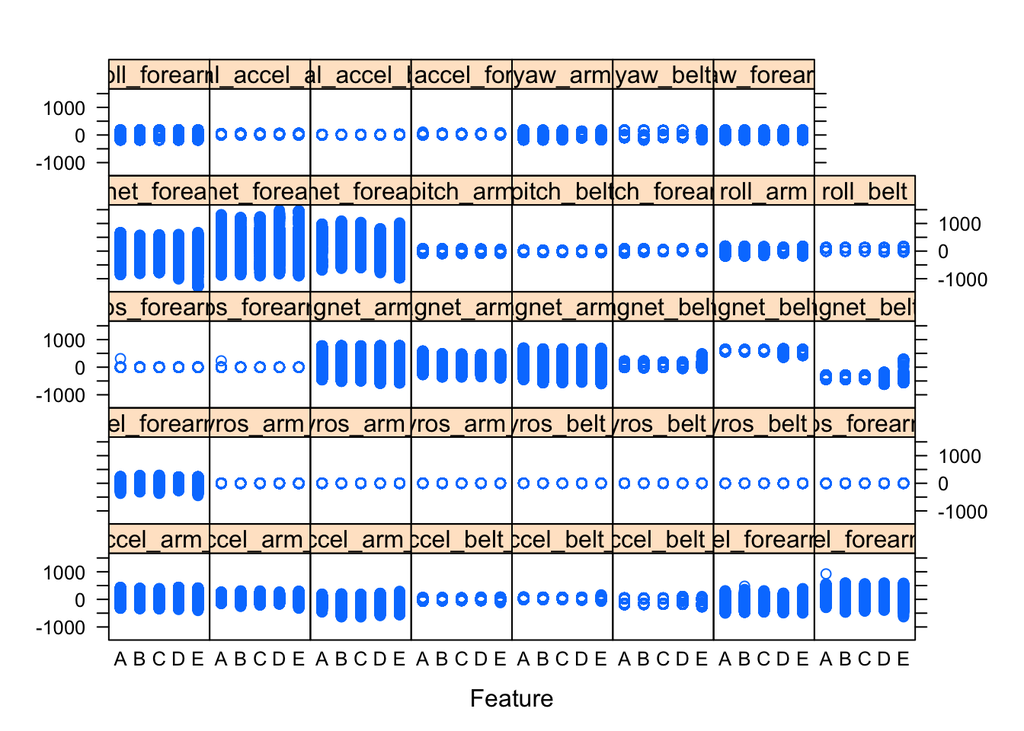

```r
featurePlot(train, outcome.org, "strip")
```

#### Correlation plot

The plot below shows average of correlation is not too high, so I choose to not perform further PCA preprocessing.

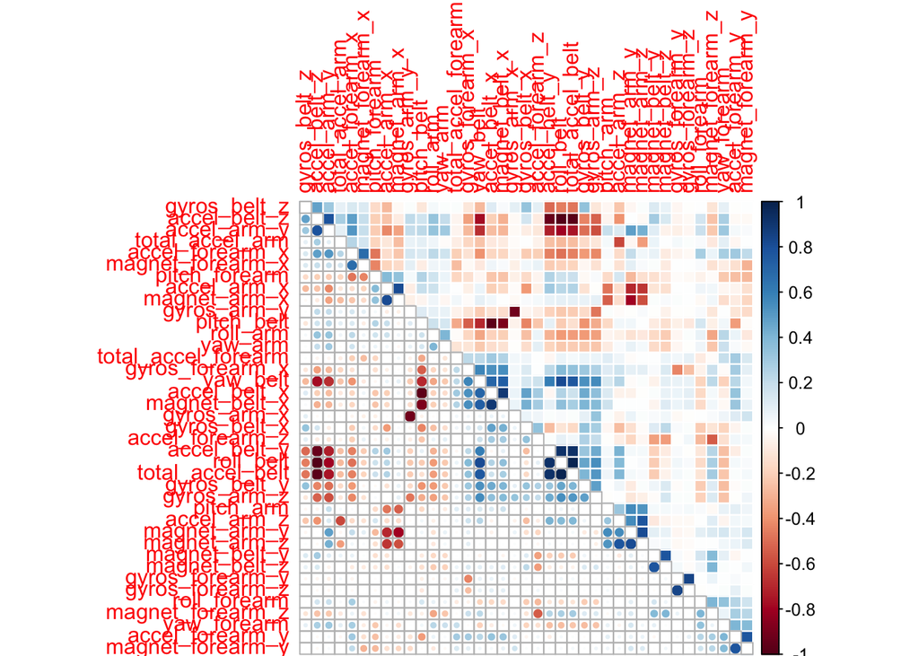

```r
corrplot.mixed(cor(train), lower="circle", upper="color",
               tl.pos="lt", diag="n", order="hclust", hclust.method="complete")
```

#### tSNE plot

```r
tsne = Rtsne(as.matrix(train), check_duplicates=FALSE, pca=TRUE,
              perplexity=30, theta=0.5, dims=2)
```

[output not shown]

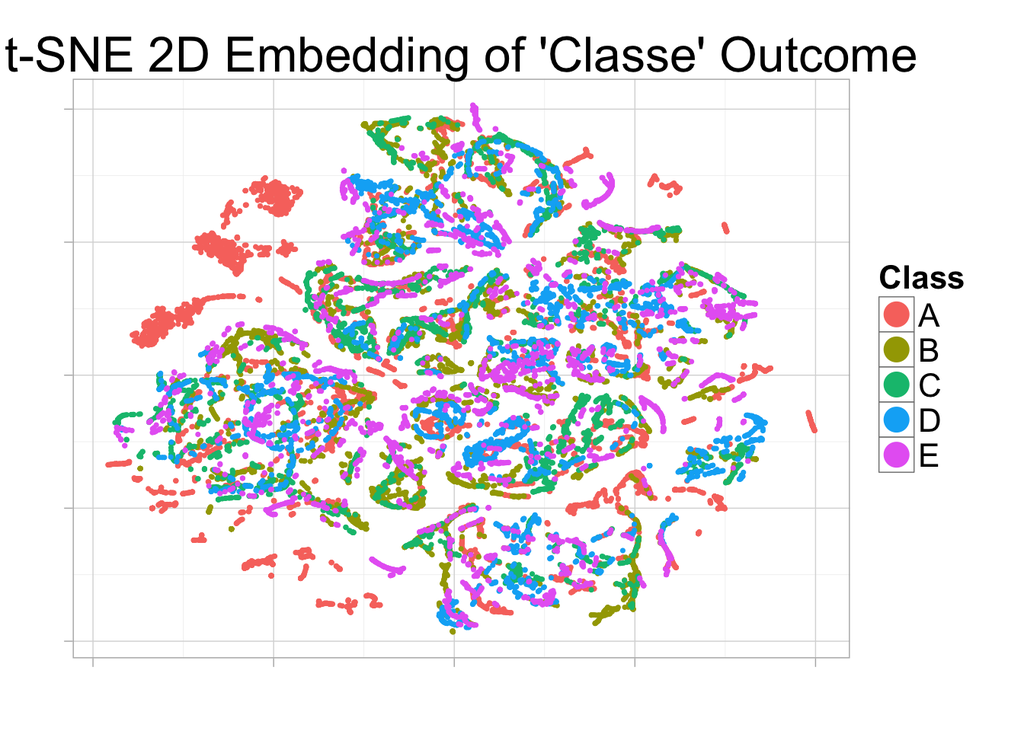

```r
embedding = as.data.frame(tsne$Y)
embedding$Class = outcome.org
g = ggplot(embedding, aes(x=V1, y=V2, color=Class)) +
  geom_point(size=1.25) +
  guides(colour=guide_legend(override.aes=list(size=6))) +
  xlab("") + ylab("") +
  ggtitle("t-SNE 2D Embedding of 'Classe' Outcome") +
  theme_light(base_size=20) +
  theme(axis.text.x=element_blank(),
        axis.text.y=element_blank())
print(g)
```

### Model Building

#### XGBoost data

XGBoost supports only numeric matrix data. Converting all training, testing and outcome data to matrix.

```r
# convert data to matrix
train.matrix = as.matrix(train)
mode(train.matrix) = "numeric"
test.matrix = as.matrix(test)
mode(test.matrix) = "numeric"
# convert outcome from factor to numeric matrix
#   xgboost takes multi-labels in [0, numOfClass)
y = as.matrix(as.integer(outcome)-1)
```

#### XGBoost parameters

Set XGBoost parameters for cross validation and training. Set a multiclass classification objective as the gradient boosting’s learning function. Set evaluation metric to merror, multiclass error rate.

```r
# xgboost parameters
param <- list("objective" = "multi:softprob",
              "num_class" = num.class,
              "eval_metric" = "merror",
              "nthread" = 8,
              "max_depth" = 16,
              "eta" = 0.3,
              "gamma" = 0,
              "subsample" = 1,
              "colsample_bytree" = 1,
              "min_child_weight" = 12 )
```

#### Expected Error Rate and Cross Fold Validation

Expected error rate is less than 1% for a good classification. Do cross validation to estimate the error rate using 4-fold cross validation, with 200 epochs to reach the expected error rate of less than 1%.

```r
# set random seed, for reproducibility
set.seed(1234)
# k-fold cross validation, with timing
nround.cv = 200
bst.cv <- xgb.cv(param=param, data=train.matrix, label=y,
              nfold=4, nrounds=nround.cv, prediction=TRUE, verbose=FALSE)
tail(bst.cv$dt)
```

```
##    train.merror.mean train.merror.std test.merror.mean test.merror.std
## 1:          0.000000         0.000000         0.006421        0.001181
## 2:          0.000000         0.000000         0.006421        0.001314
## 3:          0.000000         0.000000         0.006370        0.001215
## 4:          0.000000         0.000000         0.006421        0.001170
## 5:          0.000000         0.000000         0.006421        0.001170
## 6:          0.000000         0.000000         0.006472        0.001132
```

From the cross validation, choose index with minimum multiclass error rate. Index will be used in the model training to fulfill expected minimum error rate of < 1%.

```r
# index of minimum merror
min.merror.idx = which.min(bst.cv$dt[, test.merror.mean])
min.merror.idx
```

```
## [1] 192
```

```r
# minimum merror
bst.cv$dt[min.merror.idx,]
```

```
##    train.merror.mean train.merror.std test.merror.mean test.merror.std
## 1:          0.000000         0.000000         0.006370        0.001215
```

#### Model training

Fit the XGBoost gradient boosting model on all of the training data.

```r
bst <- xgboost(param=param, data=train.matrix, label=y,
                           nrounds=min.merror.idx, verbose=0)
```

#### Predicting the testing data

```r
# xgboost predict test data using the trained model
pred <- predict(bst, test.matrix)
head(pred, 10)
```

```
##  [1] 2.705818e-04 9.981630e-01 1.164080e-03 1.542314e-04 2.480260e-04
##  [6] 9.991264e-01 6.326562e-04 2.241193e-04 3.974486e-06 1.285406e-05
```

#### Post-processing

Output of prediction is the predicted probability of the 5 levels (columns) of outcome. Decode the quantitative 5 levels of outcomes to qualitative letters (A, B, C, D, E).

```r
# decode prediction
pred = matrix(pred, nrow=num.class, ncol=length(pred)/num.class)
pred = t(pred)
pred = max.col(pred, "last")
pred.char = toupper(letters[pred])
```

#### Feature importance

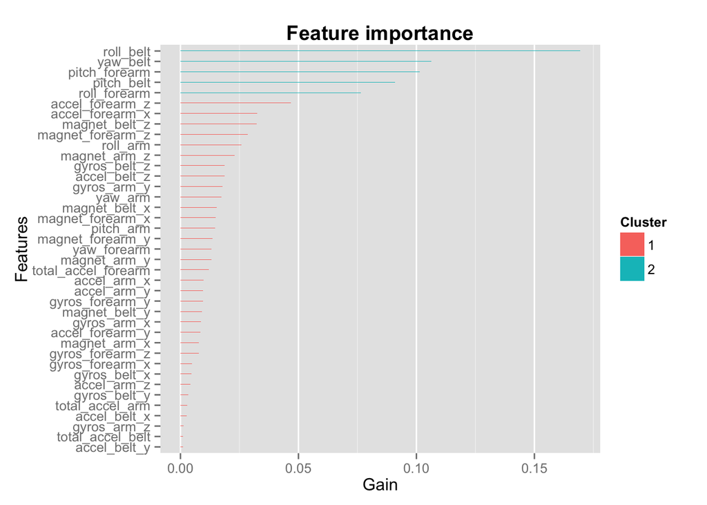

```r
# get the trained model
model = xgb.dump(bst, with.stats=TRUE)
# get the feature real names
names = dimnames(train.matrix)[[2]]
# compute feature importance matrix
importance_matrix = xgb.importance(names, model=bst)

# plot
gp = xgb.plot.importance(importance_matrix)
print(gp)
```

#### Creating submission files

```r
path = "./answer"
pml_write_files = function(x) {
    n = length(x)
    for(i in 1: n) {
        filename = paste0("problem_id_", i, ".txt")
        write.table(x[i], file=file.path(path, filename),
                    quote=FALSE, row.names=FALSE, col.names=FALSE)
    }
}
pml_write_files(pred.char)
```